# Data-606-Lab 2 - Introduction to Data

Bikash Bhowmik

2026-09-12

## The RStudio Interface

```r
data(nycflights)
```

## Exercise 1

Question 2: Are features revealed in one that are obscured in another?

## Exercise 2

Create a new data frame that includes flights headed to SFO in February, and save this data frame as sfo_feb_flights. How many flights meet these criteria?

**Answer:**

I created a new data frame, sfo_feb_flights, containing flights to SFO in February. The number of flights that meet these criteria is 68

```r
sfo_feb_flights <- nycflights %>%
  filter(dest == "SFO", month == 2)

sfo_feb_flights
```

```
## # A tibble: 68 × 16
##     year month   day dep_time dep_delay arr_time arr_delay carrier tailnum
##    <int> <int> <int>    <int>     <dbl>    <int>     <dbl> <chr>   <chr>
##  1  2013     2    18     1527        57     1903        48 DL      N711ZX
##  2  2013     2     3      613        14     1008        38 UA      N502UA
##  3  2013     2    15      955        -5     1313       -28 DL      N717TW
##  4  2013     2    18     1928        15     2239        -6 UA      N24212
##  5  2013     2    24     1340         2     1644       -21 UA      N76269
##  6  2013     2    25     1415       -10     1737       -13 UA      N532UA
##  7  2013     2     7     1032         1     1352       -10 B6      N627JB
##  8  2013     2    15     1805        20     2122         2 AA      N335AA
##  9  2013     2    13     1056        -4     1412       -13 UA      N532UA
## 10  2013     2     8      656        -4     1039        -6 DL      N710TW
## # ℹ 58 more rows
## # ℹ 7 more variables: flight <int>, origin <chr>, dest <chr>, air_time <dbl>,
## #   distance <dbl>, hour <dbl>, minute <dbl>
```

QUESTION: How many flights meet these criteria? ANSWER: 68 Flights

```r
sfo_feb_flights %>% summarise( n_flights = n())
```

```
## # A tibble: 1 × 1
##   n_flights
##       <int>
## 1        68
```

## Exercise 3

Describe the distribution of the arrival delays of these flights using a histogram and appropriate summary statistics. Hint: The summary statistics you use should depend on the shape of the distribution.

**Answer:**

The histogram shows that arrival delays are right-skewed, with most flights having shorter delays and a few flights having very large delays. Therefore, the median and IQR are appropriate summary statistics for describing the distribution.

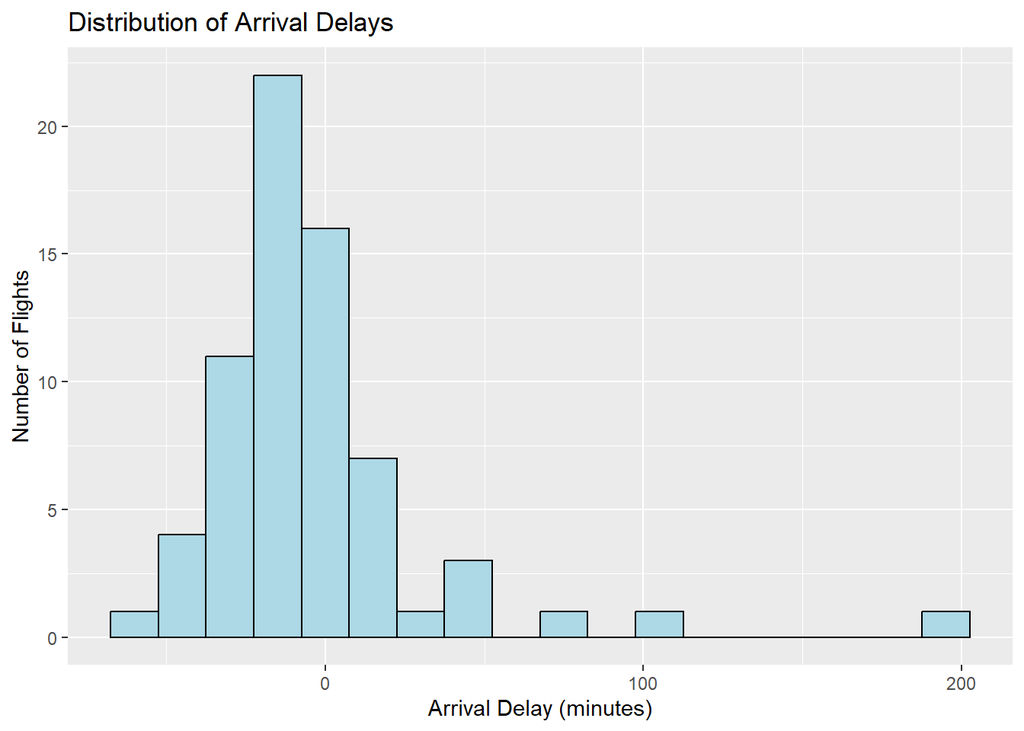

```r
ggplot(data = sfo_feb_flights, aes(x = arr_delay)) +
  geom_histogram(binwidth = 15, fill = "lightblue", color = "black") +
  labs(
    title = "Distribution of Arrival Delays",
    x = "Arrival Delay (minutes)",
    y = "Number of Flights"
  )
```

## Exercise 4

Calculate the median and interquartile range for arr_delays of flights in in the sfo_feb_flights data frame, grouped by carrier. Which carrier has the most variable arrival delays?

**Answer:**

The median and IQR of arrival delays were calculated for each carrier. DL and UA have the most variable arrival delays because they have the largest IQR values.

```r
sfo_feb_flights %>%
  group_by(carrier) %>%
    summarise(median = median(arr_delay), IQR = IQR(arr_delay)) %>%
      arrange(desc(IQR))
```

```
## # A tibble: 5 × 3
##   carrier median   IQR
##   <chr>    <dbl> <dbl>
## 1 DL       -15    22
## 2 UA       -10    22
## 3 VX       -22.5  21.2
## 4 AA         5    17.5
## 5 B6       -10.5  12.2
```

## Exercise 5

Suppose you really dislike departure delays and you want to schedule your travel in a month that minimizes your potential departure delay leaving NYC. One option is to choose the month with the lowest mean departure delay. Another option is to choose the month with the lowest median departure delay. What are the pros and cons of these two choices?

**Answer:**

The mean is the average of the entire Flight data set so in this case the average departure delay will not be as accurate as the median departure delay which is the middle of the data set.

On time departure rate for NYC airports

```r
nycflights <- nycflights %>%
  mutate(dep_type = ifelse(dep_delay < 5, "on time", "delayed"))

nycflights %>%
  group_by(origin) %>%
  summarise(ot_dep_rate = sum(dep_type == "on time") / n()) %>%
  arrange(desc(ot_dep_rate))
```

```
## # A tibble: 3 × 2
##   origin ot_dep_rate
##   <chr>        <dbl>
## 1 LGA          0.728
## 2 JFK          0.694
## 3 EWR          0.637
```

## Exercise 6

If you were selecting an airport simply based on on time departure percentage, which NYC airport would you choose to fly out of?

**Answer:**

I would choose to fly out of LGA based on the fact that LGA have the highest on time departure rate.

You can also visualize the distribution of on on time departure rate across the three airports using a segmented bar plot.

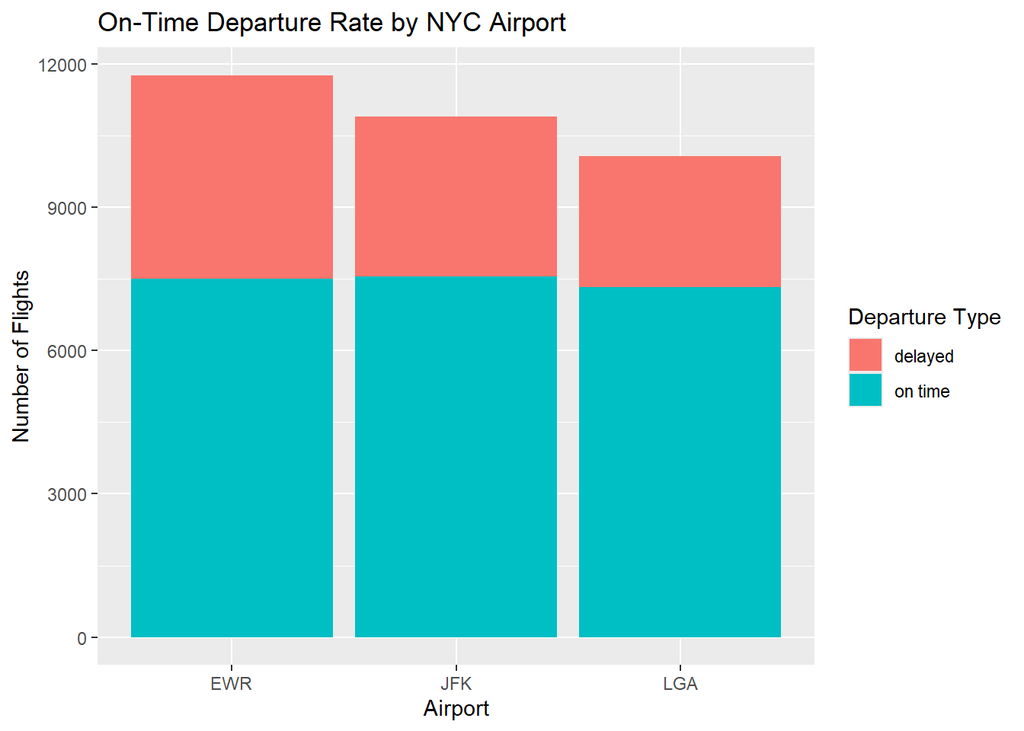

```r
ggplot(data = nycflights, aes(x = origin, fill = dep_type)) +
  geom_bar() +
  labs(
    title = "On-Time Departure Rate by NYC Airport",
    x = "Airport",
    y = "Number of Flights",
    fill = "Departure Type"
  )
```

## Exercise 7

**Answer:**

Mutate the data frame so that it includes a new variable that contains the average speed, avg_speed traveled by the plane for each flight (in mph). Hint: Average speed can be calculated as distance divided by number of hours of travel, and note that air_time is given in minutes.

**Answer:**

```r
nycflights <- nycflights %>%
  mutate(avg_speed = distance / (air_time / 60))

nycflights
```

```
## # A tibble: 32,735 × 18
##     year month   day dep_time dep_delay arr_time arr_delay carrier tailnum
##    <int> <int> <int>    <int>     <dbl>    <int>     <dbl> <chr>   <chr>
##  1  2013     6    30      940        15     1216        -4 VX      N626VA
##  2  2013     5     7     1657        -3     2104        10 DL      N3760C
##  3  2013    12     8      859        -1     1238        11 DL      N712TW
##  4  2013     5    14     1841        -4     2122       -34 DL      N914DL
##  5  2013     7    21     1102        -3     1230        -8 9E      N823AY
##  6  2013     1     1     1817        -3     2008         3 AA      N3AXAA
##  7  2013    12     9     1259        14     1617        22 WN      N218WN
##  8  2013     8    13     1920        85     2032        71 B6      N284JB
##  9  2013     9    26      725       -10     1027        -8 AA      N3FSAA
## 10  2013     4    30     1323        62     1549        60 EV      N12163
## # ℹ 32,725 more rows
## # ℹ 9 more variables: flight <int>, origin <chr>, dest <chr>, air_time <dbl>,
## #   distance <dbl>, hour <dbl>, minute <dbl>, dep_type <chr>, avg_speed <dbl>
```

## Exercise 8

Make a scatterplot of avg_speed vs. distance. Describe the relationship between average speed and distance. Hint: Use geom_point().

**Answer:**

The scatterplot shows a positive relationship between distance and average speed. In general, flights traveling longer distances tend to have higher average speeds.

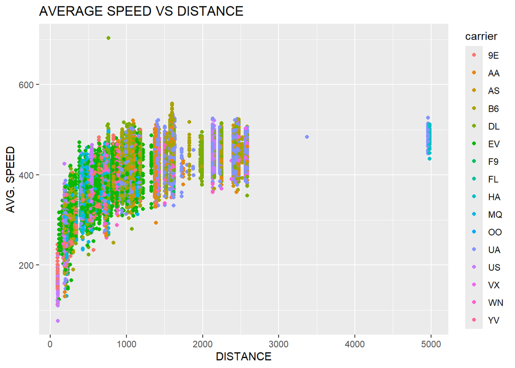

```r
ggplot(data = nycflights, aes(x = distance, y = avg_speed, color= carrier)) + geom_point()+
       labs(title = "AVERAGE SPEED VS DISTANCE", x = "DISTANCE", y = "AVG. SPEED")
```

## Exercise 9

Replicate the following plot. Hint: The data frame plotted only contains flights from American Airlines, Delta Airlines, and United Airlines, and the points are colored by carrier. Once you replicate the plot, determine (roughly) what the cutoff point is for departure delays where you can still expect to get to your destination on time.

**Answer:**

The cutoff point for departure delays where you can still expect to get to your destination on time seems to be somewhere between 50 and 60 mins.

[figure not shown]

```r
nycflightsF <- nycflights %>%
  filter(carrier == "AA" | carrier == "DL" | carrier == "UA")

ggplot(data = nycflightsF, aes(x = dep_delay, y = arr_delay, color= carrier)) + geom_point()+
       labs(title = "AVERAGE SPEED VS DISTANCE", x = "DISTANCE", y = "AVG. SPEED")
```